ΒΙΟΣΤΑΤΙΣΤΙΚΗ

Παναγούλα Λέκκα  
ΔΠΜΣ Ψηφιακές Υπηρεσίες Υγείας & Αναλυτική  
dha202204@hua

# ΕΡΓΑΣΙΑ 1Η: ΠΕΡΙΓΡΑΦΙΚΗ ΣΤΑΤΙΣΤΙΚΗ - ΕΠΑΓΩΓΙΚΗ ΣΤΑΤΙΣΤΙΚΗ

## Εισαγωγή

Οι μεταβλητές είναι οι ακόλουθες:

| Όνομα μεταβλητής | Περιγραφή (μονάδες) |
| --- | --- |
| age | Ηλικία |
| sex | Φύλο: Άνδρας=1, Γυναίκα=0 |
| bmi | Δείκτης μάζας σώματος |
| bmi_grou | Επίπεδο δείκτη μάζας σώματος, Ελλιποβαρής=0, Φυσιολογικός=1, Υπέρβαρος=2, Παχύσαρκος=3 |
| cursmok | Κάπνισμα: Ναι=1, Όχι=0 |
| educat | Χρόνια εκπαίδευσης |
| family | Οικογενειακή κατάσταση: Άγαμος=1, Συζευγμένος=2, Διαζευγμένος=3, Χήρος=4 |
| financia | Επιπεδο οικονομικού εισοδηματος: Χαμηλό=1, Μέτριο=2, Υψηλό=3 |
| PhysActivity | Σωματική άσκηση: Ναι=1, Όχι=0 |
| HTN | Υψηλή πίεση: Ναι=1, Όχι=0 |
| sbp | Συστολική πίεση |
| dbp | Διαστολική πίεση |
| DM | Ζαχαρώδης διαβήτης: Ναι=1, Όχι=0 |
| HCHOL | Υψηλή χοληστερίνη: Ναι=1, Όχι=0 |
| cholest | Χοληστερίνη |
| tgl | Τριγλυκερίδια |
| hdl | Καλή χοληστερόλη |
| ldl | Κακή χοληστερόλη |
| MS | Μεταβολικό σύνδρομο: Ναι=1, Όχι=0 |
| MedDietScore | Δείκτης μεσογειακής διατροφής |
| CVD_10_yr | Εμφάνιση καρδιαγγειακής νόσου κατά τη χρονική περίοδο 10 ετων: Ναι=1, Όχι=0 |
| FU | Χρονική περίοδος της πρώτης εμφάνισης της νόσου εντός της δεκαετίας |
| HellenicSCORE | Πιθανότητα εμφάνισης καρδιαγγειακής νόσου εντός της δεκαετίας |

## Προετοιμασία

### Βιβλιοθήκες & Dataset

```r
#define packages to install
packages <- c('readxl', 'csvread', 'moments', 'openxlsx', 'MASS', 'lmtest', 'ggplot2', 'caTools', 'car', 'scatterplot3d')

#install all packages that are not already installed
install.packages(setdiff(packages, rownames(installed.packages())))

library(readxl)
library(csvread)
library(moments)
library(openxlsx)
library(MASS)
library(lmtest)
library("ggplot2")
library(caTools)
# sudo apt-get install libnlopt-dev
library(car)
library("scatterplot3d")

BioDS<-read_xlsx("./BIOSTATISTICS_ATTICA_10YS_STUDY.xlsx")
# View(BioDS)
```

### Έλεγχος Δεδομένων

```r
summary(BioDS)
```

```
      age             sex              bmi           bmi_grou
 Min.   :18.00   Min.   :0.0000   Min.   :16.02   Min.   :0.000
 1st Qu.:30.00   1st Qu.:0.0000   1st Qu.:22.44   1st Qu.:1.000
 Median :42.00   Median :0.0000   Median :25.39   Median :2.000
 Mean   :41.24   Mean   :0.4896   Mean   :25.75   Mean   :1.658
 3rd Qu.:51.00   3rd Qu.:1.0000   3rd Qu.:28.70   3rd Qu.:2.000
 Max.   :87.00   Max.   :1.0000   Max.   :52.52   Max.   :3.000
                                  NA's   :1
    cursmok          educat          family         financia
 Min.   :0.000   Min.   : 5.00   Min.   :1.000   Min.   :1.000
 1st Qu.:0.000   1st Qu.:12.00   1st Qu.:1.000   1st Qu.:1.000
 Median :0.000   Median :12.00   Median :2.000   Median :2.000
 Mean   :0.455   Mean   :12.84   Mean   :1.732   Mean   :2.231
 3rd Qu.:1.000   3rd Qu.:16.00   3rd Qu.:2.000   3rd Qu.:3.000
 Max.   :1.000   Max.   :22.00   Max.   :4.000   Max.   :4.000
                 NA's   :1
  PhysActivity         HTN              sbp             dbp
 Min.   :0.0000   Min.   :0.0000   Min.   : 75.0   Min.   : 40.00
 1st Qu.:0.0000   1st Qu.:0.0000   1st Qu.:110.0   1st Qu.: 70.00
 Median :0.0000   Median :0.0000   Median :120.0   Median : 80.00
 Mean   :0.4434   Mean   :0.2956   Mean   :121.3   Mean   : 78.91
 3rd Qu.:1.0000   3rd Qu.:1.0000   3rd Qu.:130.0   3rd Qu.: 85.00
 Max.   :1.0000   Max.   :1.0000   Max.   :200.0   Max.   :130.00

       DM             HCHOL           cholest           tgl
 Min.   :0.0000   Min.   :0.0000   Min.   : 96.9   Min.   : 27.0
 1st Qu.:0.0000   1st Qu.:0.0000   1st Qu.:159.8   1st Qu.: 62.0
 Median :0.0000   Median :0.0000   Median :185.3   Median : 89.0
 Mean   :0.0485   Mean   :0.3764   Mean   :188.0   Mean   :106.7
 3rd Qu.:0.0000   3rd Qu.:1.0000   3rd Qu.:214.2   3rd Qu.:133.0
 Max.   :1.0000   Max.   :1.0000   Max.   :371.4   Max.   :587.0

      hdl            ldl               MS          MedDietScore
 Min.   :23.0   Min.   : 29.30   Min.   :0.0000   Min.   : 3.00
 1st Qu.:40.0   1st Qu.: 90.85   1st Qu.:0.0000   1st Qu.:25.10
 Median :48.0   Median :113.05   Median :0.0000   Median :26.71
 Mean   :49.7   Mean   :116.98   Mean   :0.1824   Mean   :26.78
 3rd Qu.:57.0   3rd Qu.:141.00   3rd Qu.:0.0000   3rd Qu.:28.50
 Max.   :94.0   Max.   :298.05   Max.   :1.0000   Max.   :55.00

   CVD_10_yr            FU         HellenicSCORE
 Min.   :0.0000   Min.   : 2.000   Min.   :0.0000000
 1st Qu.:0.0000   1st Qu.: 4.000   1st Qu.:0.0000317
 Median :0.0000   Median :10.000   Median :0.0061969
 Mean   :0.1247   Mean   : 8.039   Mean   :0.0205380
 3rd Qu.:0.0000   3rd Qu.:10.000   3rd Qu.:0.0293048
 Max.   :1.0000   Max.   :10.000   Max.   :0.3870150
```

Παρατηρούμε ότι οι μεταβλητές bmi και educat έχουν Null τιμές και θα σβήσουμε τις αντίστοιχες εγγραφές.

```r
# bmi null row
delrow1 <- which(is.na(BioDS$bmi))
if (length(delrow1) != 0) {
    BioDS <- BioDS[-delrow1,]
    }
# educat null row
delrow2 <- which(is.na(BioDS$educat))
if (length(delrow2) != 0) {
    BioDS <- BioDS[-delrow2,]
    }

# Replace values of 4 with 3 in the "financia" column of the BioDS data frame
BioDS$financia <- ifelse(BioDS$financia == 4, 3, BioDS$financia)

# write.xlsx(BioDS, "./BioDS_Clean.xlsx")
# View(BioDS)

# count rows of dataset
print(paste('Το μέγεθος του δείγματος είναι:',nrow(BioDS)))
```

```
[1] "Το μέγεθος του δείγματος είναι: 431"
```

## A: Ποσοτικές Μεταβλητές: Περιγραφικά Μέτρα - Γραφικοί Τρόποι Παρουσίασης

### Α.1

Να υπολογίσετε τα κυριότερα μέτρα θέσης, μέτρα διασποράς και μέτρα μορφής των μεταβλητών του δείκτης μάζας σώματος, της συστολικής και διαστολικής πίεσης, των τριγλυκεριδίων, της καλής και κακής χοληστερόλης και του δείκτη μεσογειακής διατροφής. Να κατασκευάσετε τα ιστόγραμμα σχετικών συχνοτήτων και τις αντίστοιχες πολυγωνικες γραμμές. Σχολιάστε.

Θα υλοποιήσουμε τις δύο παρακάτω συναρτήσεις που παίρνουν παράμετρο τη μεταβλητή που θέλουμε να εξετάσουμε και επιστρέφουν:

- **fnmeasures**: βασικά μέτρα θέσης, μέτρα διασποράς και μετρα μορφής
- **fnplots**: ένα διάγραμμα με το ιστόγραμμα σχετικών συχνοτήτων και ένα διάγραμμα με την πολυγωνική γραμμή

```r
fnmeasures <- function(data) {
    out<-summary(data)
    out['Var']<-var(data)
    out['Stand.Dev.']<-sd(data)
    # Συντελεστής Ασυμμετρίας
    out['Skewness']<-skewness(data)
    # Συντελεστής Κυρτότητας
    out['Kurtosis']<-kurtosis(data)
    # Αριθμός Εγγραφών
    out['Count']<-length(data)
    return(out)
}

fnplots <- function(data) {
    measname<-substitute(data)
    title<-paste("Histogram of ",measname," with Normal Curve")
    h<-hist(data, breaks=7, xlab=measname, main=title)
    xfit<-seq(min(data),max(data),length=50)
    yfit<-dnorm(xfit,mean=mean(data),sd=sd(data))
    yfit<-yfit*diff(h$mids[1:2])*length(data)
    lines(xfit, yfit, col="blue", lwd=2)
    plot(density(data))
}
```

#### Δείκτης Μάζας Σώματος

```
      Min.    1st Qu.     Median       Mean    3rd Qu.       Max.        Var
   16.0231    22.4014    25.3906    25.7446    28.7094    52.5192    20.8873
Stand.Dev.   Skewness   Kurtosis      Count
    4.5703     0.8373     5.1825   431.0000
```

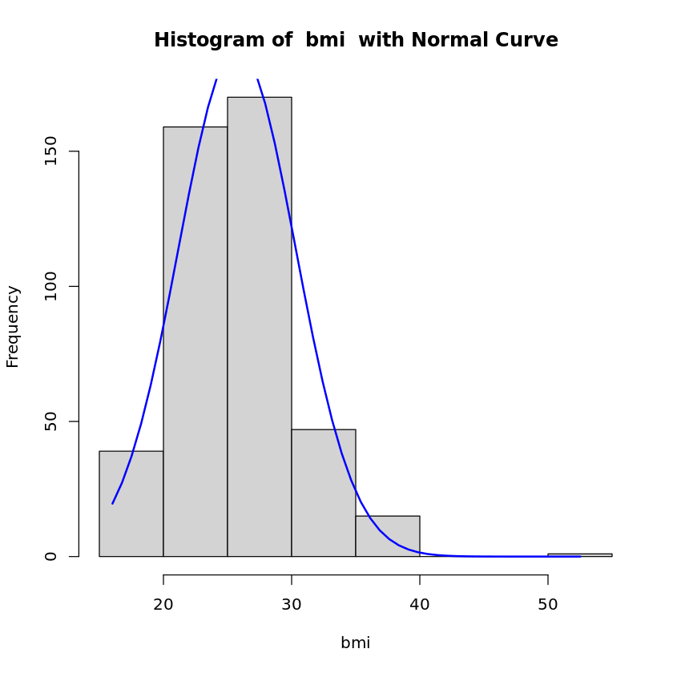

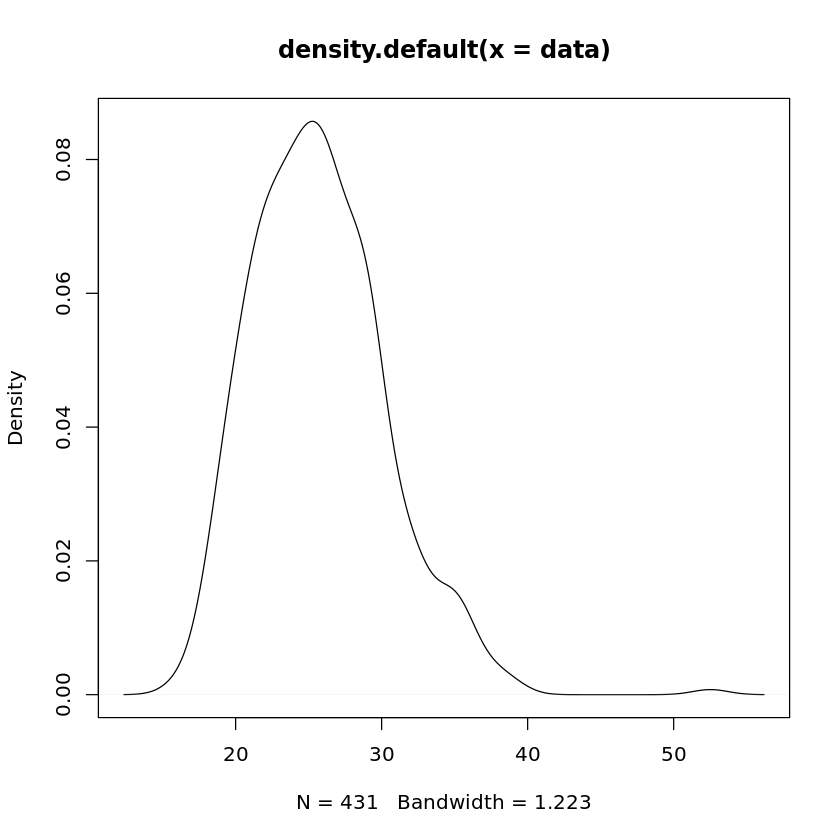

```r
bmi<-BioDS$bmi

fnmeasures(bmi)
fnplots(bmi)
```

- Από τα 431 άτομο που εξετάστηκαν στο δείγμα η ελάχιστη τιμή του Δείκτη Μάζας Σώματος είναι 16 και η μέγιστη 52.52.
- Ο μέσος όρος του Δείκτη Μάζας Σώματος είναι 25.744 λίγο μεγαλύτερος από τη διάμεσος που είναι 25.39.
- Ο Συντελεστής Ασυμμετρίας είναι θετικός 0.84, βρίσκεται στο εύρος -2 έως 2, πράγμα το οποίο αποτελεί ένδειξη ότι η κατανομή τείνει στην Κανονική. Αυτό φαίνεται και από την προσαρμοσμένη κανονική κατανομή που υπάρχει στο ιστόγραμμα με μπλε χρώμα.
- Ο Συντελεστής Κυρτότητας είναι 5.18, επειδή είναι μεγαλύτερος του 2 σημαίνει ότι η καμπύλη του Δείκτη Μάζας Σώματος είναι λεπτόκυρτη μεταβλητή.
- Η πολυγωνική γραμμή είναι μονοκόρυφη, παρουσιάζει θετική ασυμμετρία και δεν είναι πλήρως συμμετρική αφού ο μέσος διαφέρει λίγο από τη διάμεσο.

#### Συστολική Πίεση

```
      Min.    1st Qu.     Median       Mean    3rd Qu.       Max.        Var
   75.0000   110.0000   120.0000   121.2367   130.0000   200.0000   349.3299
Stand.Dev.   Skewness   Kurtosis      Count
   18.6904     0.7296     3.9617   431.0000
```

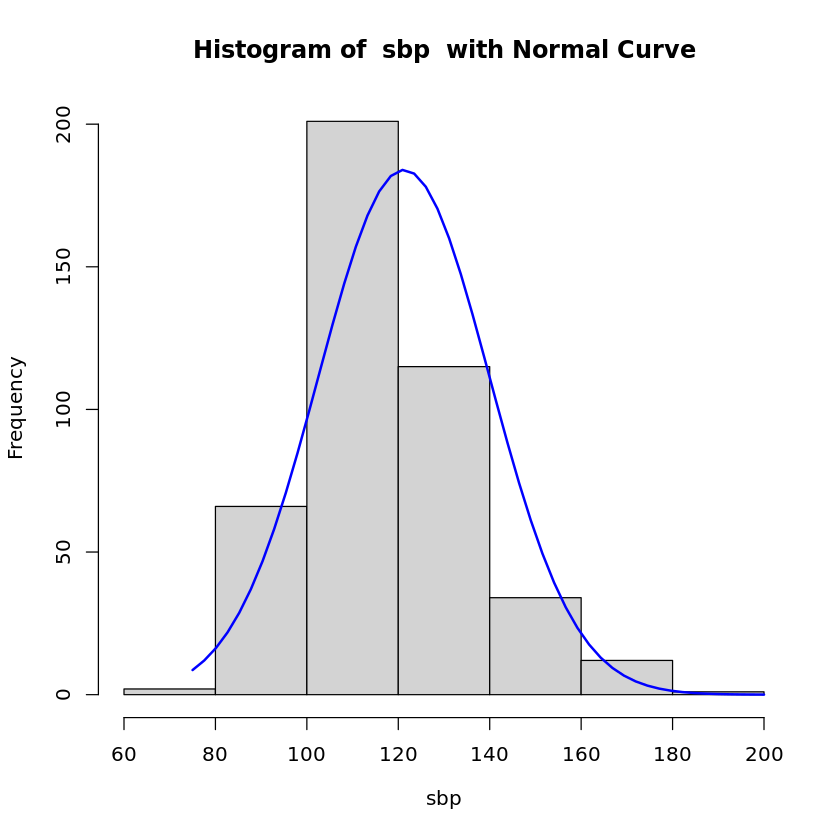

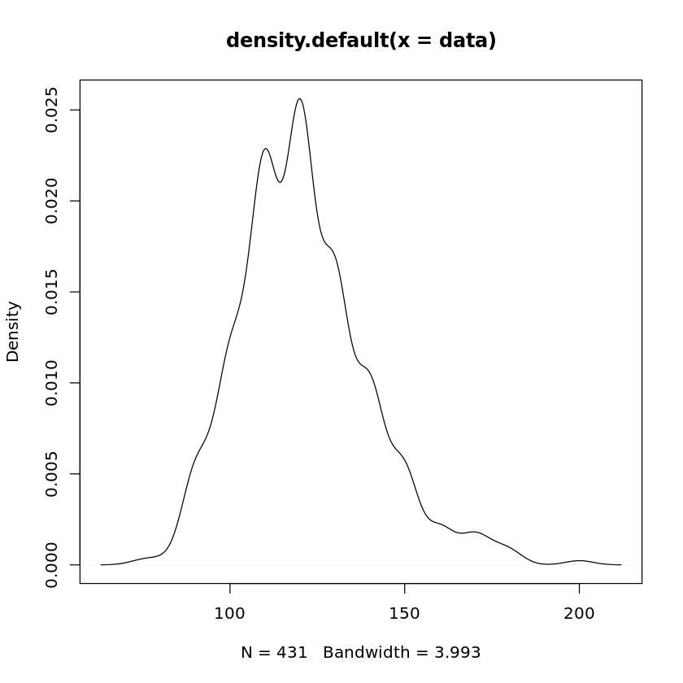

```r
sbp<-BioDS$sbp

fnmeasures(sbp)
fnplots(sbp)
```

- Η ελάχιστη Συστολική Πίεση είναι 75 και η μέγιστη 200.
- Ο μέσος όρος είναι 121.24 λίγο μεγαλύτερος από τη διάμεσος που είναι 120.
- Ο Συντελεστής Ασυμμετρίας είναι θετικός 0.7296, άρα έχουμε ελαφρώς θετική ασυμμετρία αλλά είναι κοντά στο 0 και άρα η κατανομή τείνει στην Κανονική.
- Ο Συντελεστής Κυρτότητας είναι 3.9617, λίγο μεγαλύτερος του 2 και άρα σχετικά λεπτόκυρτη.
- Η πολυγωνική γραμμή είναι δικόρυφη, με μικρή θετική ασυμμετρία.

#### Διαστολική Πίεση

```
      Min.    1st Qu.     Median       Mean    3rd Qu.       Max.        Var
   40.0000    70.0000    80.0000    78.8794    85.0000   130.0000   146.2226
Stand.Dev.   Skewness   Kurtosis      Count
   12.0923     0.3698     3.7126   431.0000
```

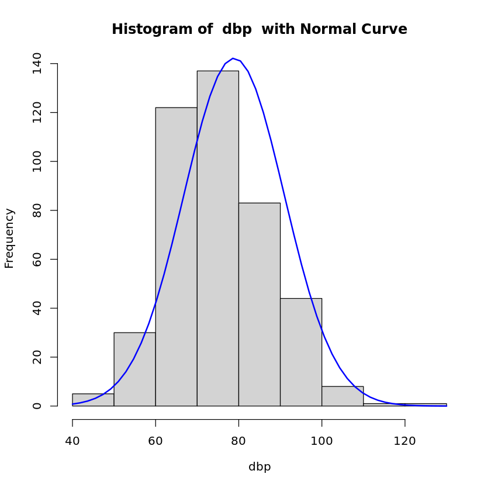

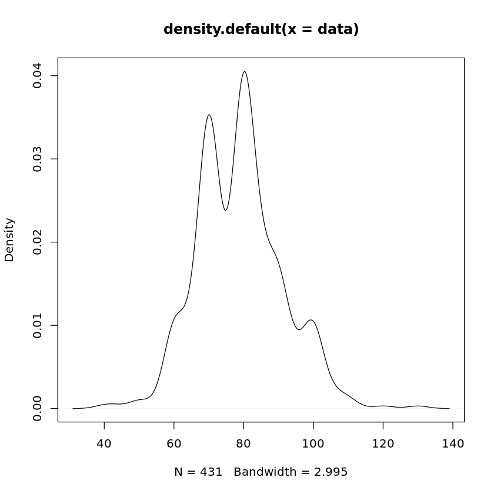

```r
dbp<-BioDS$dbp

fnmeasures(dbp)
fnplots(dbp)
```

- Η ελάχιστη Διαστολική Πίεση είναι 40 και η μέγιστη 130.
- Ο μέσος όρος είναι 78.88 λίγο μικρότερος από τη διάμεσος που είναι 80.
- Ο Συντελεστής Ασυμμετρίας είναι 0.37 θετικός και πολύ κοντά στο 0, άρα η κατανομή τείνει περισσότερο στην Κανονική.
- Ο Συντελεστής Κυρτότητας είναι 3.71, μεγαλύτερος του 2 συνεπώς η Διαστολική Πίεση είναι λεπτόκυρτη.
- Η πολυγωνική γραμμή είναι δικόρυφη, με μικρή θετική ασυμμετρία.

#### Τριγλυκερίδια

```
      Min.    1st Qu.     Median       Mean    3rd Qu.       Max.        Var
    27.000     62.000     88.000    106.174    132.000    587.000   4421.512
Stand.Dev.   Skewness   Kurtosis      Count
    66.494      2.588     15.054    431.000
```

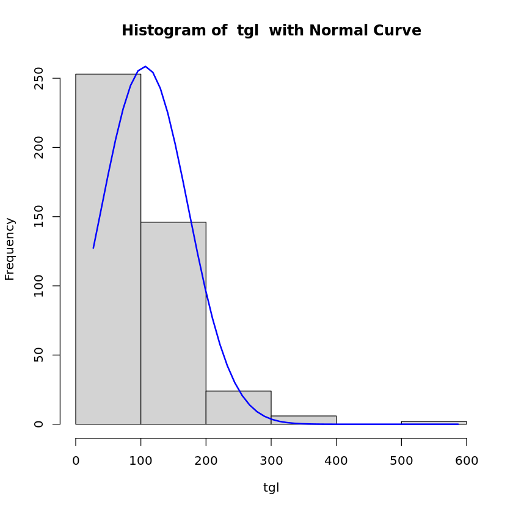

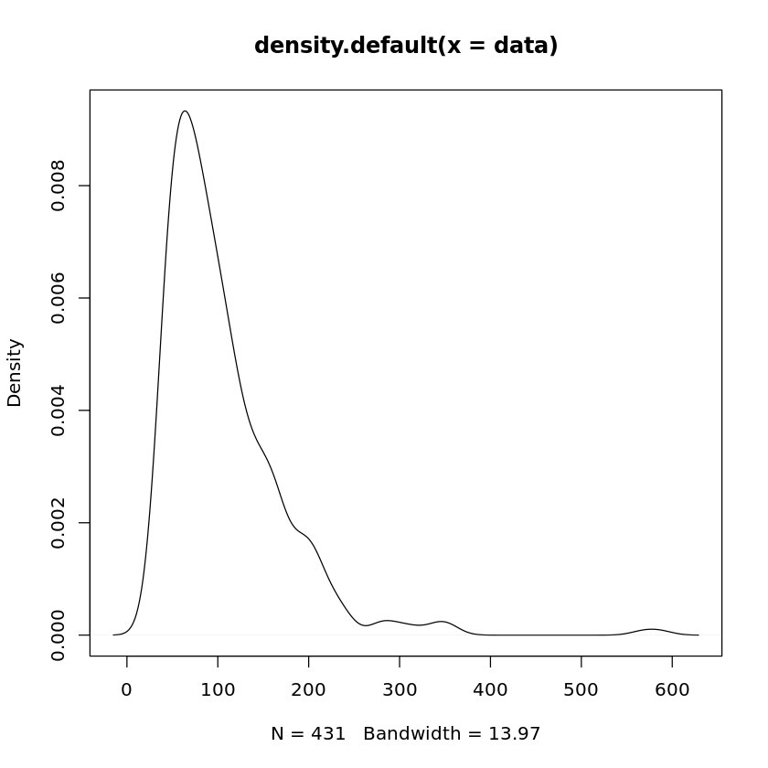

```r
tgl<-BioDS$tgl

fnmeasures(tgl)
fnplots(tgl)
```

- Η ελάχιστη τιμή για τα Τριγλυκερίδια είναι 27 και η μέγιστη 587. Παρουσιάζεται μεγάλο εύρος τιμών.
- Ο μέσος είναι 106.17 μεγαλύτερος από τη διάμεσο που είναι 88.
- Η τυπική απόκλιση είναι αυξημένη πράγμα που σημαίνει ότι οι υπάρχουν αρκετές τιμές μακριά από το μέσο.
- Ο Συντελεστής Ασυμμετρίας είναι 2.59 θετικός, συνεπώς έχουμε θετική ασυμμετρία.
- Ο Συντελεστής Κυρτότητας είναι 15.05, αρκετά μεγαλύτερος του 2, άρα η μεταβλητή μας έχει λεπτόκυρτη καμπύλη.
- Η πολυγωνική γραμμή είναι μονοκόρυφη, με αρκετά θετική ασυμμετρία.

#### Καλή Χοληστερόλη

```
      Min.    1st Qu.     Median       Mean    3rd Qu.       Max.        Var
   23.0000    40.5000    49.0000    49.7935    57.0000    94.0000   162.9642
Stand.Dev.   Skewness   Kurtosis      Count
   12.7657     0.6235     3.1803   431.0000
```

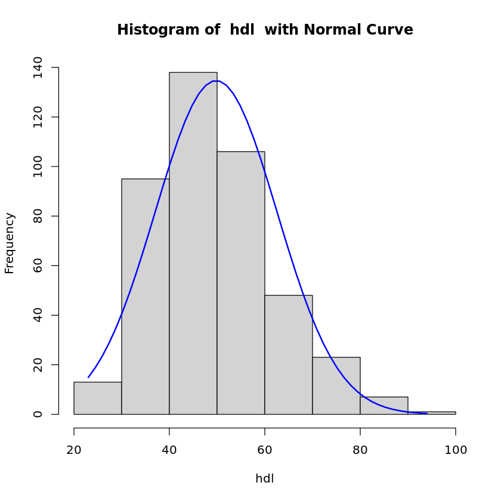

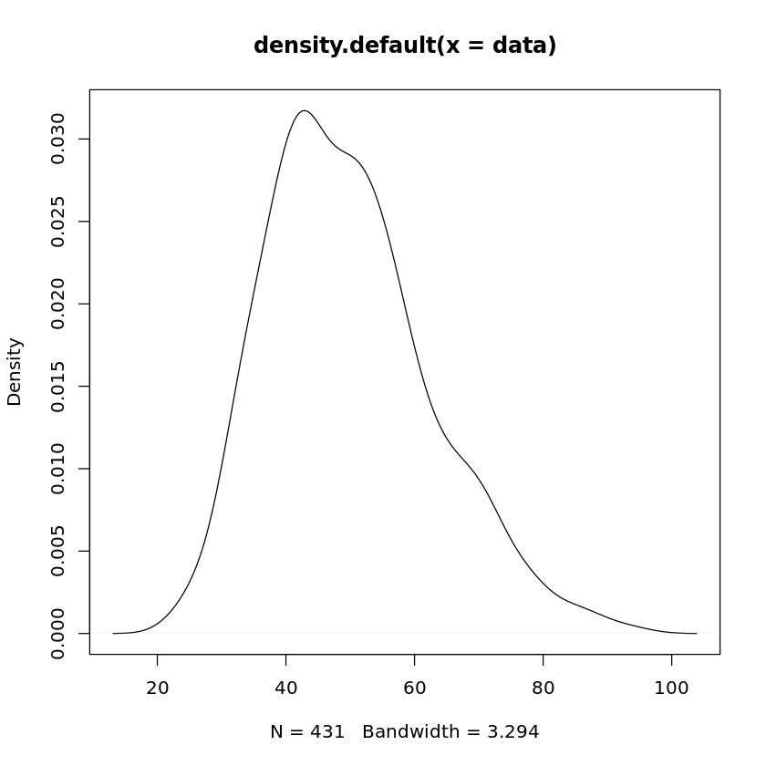

```r
hdl<-BioDS$hdl

fnmeasures(hdl)
fnplots(hdl)
```

- Η ελάχιστη τιμή για την Καλή Χοληστερόλη είναι 23 και η μέγιστη 94.
- Ο μέσος όρος είναι 49.79 λίγο μεγαλύτερος από τη διάμεσος που είναι 49.
- Ο Συντελεστής Ασυμμετρίας είναι 0.62 θετικός και κοντά στο 0, άρα η κατανομή τείνει στην Κανονική.
- Ο Συντελεστής Κυρτότητας είναι 3.18, μεγαλύτερος του 2 συνεπώς όπως φαίνεται και στο διάγραμμα η καμπύλη είναι λεπτόκυρτη.
- Η πολυγωνική γραμμή είναι μονοκόρυφη, με μικρή θετική ασυμμετρία.

#### Κακή Χοληστερόλη

```
      Min.    1st Qu.     Median       Mean    3rd Qu.       Max.        Var
   29.3000    90.6750   112.8000   116.8631   140.9000   298.0500  1408.4762
Stand.Dev.   Skewness   Kurtosis      Count
   37.5297     0.6421     4.2560   431.0000
```

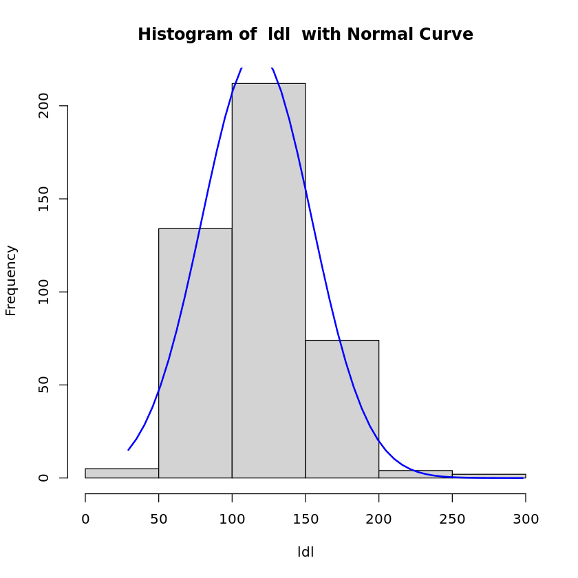

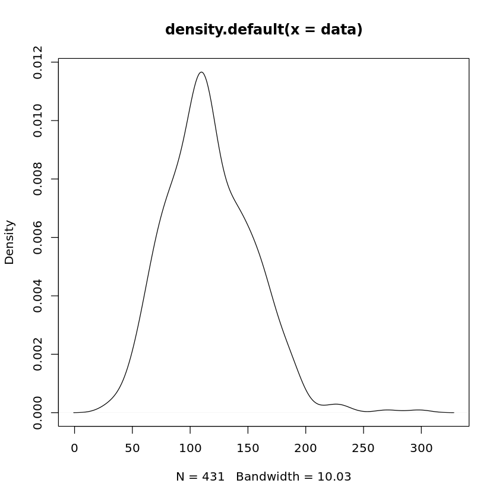

```r
ldl<-BioDS$ldl

fnmeasures(ldl)
fnplots(ldl)
```

- Η ελάχιστη τιμή για την Κακή Χοληστερόλη είναι 29.3 και η μέγιστη 298.05.
- Ο μέσος όρος είναι 116.86 λίγο μεγαλύτερος από τη διάμεσος που είναι 112.8.
- Ο Συντελεστής Ασυμμετρίας είναι 0.64 θετικός και κοντά στο 0, άρα η κατανομή τείνει στην Κανονική.
- Ο Συντελεστής Κυρτότητας είναι 4.25, συνεπώς όπως φαίνεται και στο διάγραμμα η καμπύλη είναι λεπτόκυρτη.
- Η πολυγωνική γραμμή είναι μονοκόρυφη, με μικρή θετική ασυμμετρία.

#### Δείκτης Μεσογειακής Διατροφής

```
      Min.    1st Qu.     Median       Mean    3rd Qu.       Max.        Var
     3.000     25.122     26.709     26.779     28.487     55.000     60.556
Stand.Dev.   Skewness   Kurtosis      Count
     7.782      1.207      7.956    431.000
```

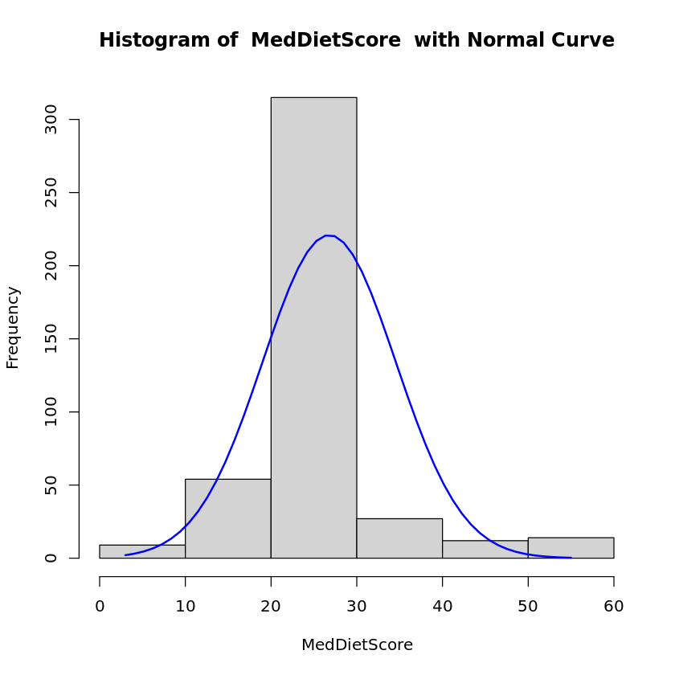

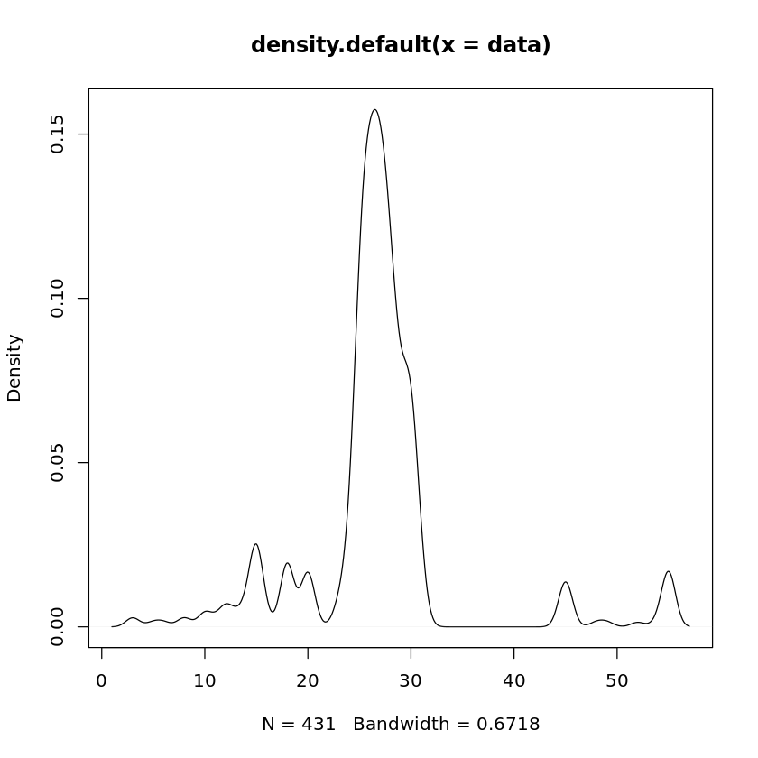

```r
MedDietScore<-BioDS$MedDietScore

fnmeasures(MedDietScore)
fnplots(MedDietScore)
```

### Α.2

Να υπολογίσετε τα κυριότερα μέτρα θέσης, μέτρα διασποράς και μέτρα μορφής των μεταβλητών του δείκτης μάζας σώματος, της συστολικής και διαστολικής πίεσης, των τριγλυκεριδίων, της καλής και κακής χοληστερόλης και του δείκτη μεσογειακής διατροφής για τους καπνιστες και μη. Να κατασκευασετε τα αντίστοιχα θηκογράμματα. Σχολιάστε.

#### Δείκτης Μάζας Σώματος - Καπνιστές & Μη

A matrix: 2 × 11 of type dbl

|  | Min. | 1st Qu. | Median | Mean | 3rd Qu. | Max. | Var | Stand.Dev. | Skewness | Kurtosis | Count |
| --- | --- | --- | --- | --- | --- | --- | --- | --- | --- | --- | --- |
| bmismok1_meas | 18.04270 | 22.60110 | 25.59374 | 25.88114 | 28.70619 | 52.51917 | 20.91015 | 4.572762 | 1.3308383 | 7.963542 | 195 |
| bmismok0_meas | 16.02307 | 22.03686 | 25.35154 | 25.63177 | 28.70593 | 38.56749 | 20.92911 | 4.574834 | 0.4324469 | 2.810220 | 236 |

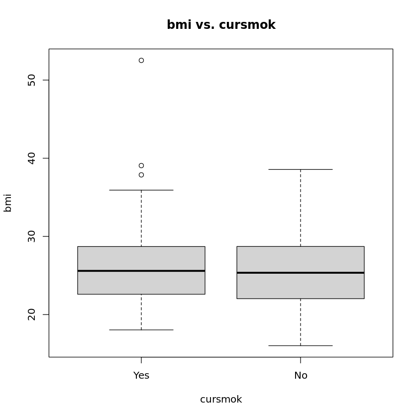

```r
bmismok1<-BioDS$bmi[BioDS$cursmok==1]
bmismok0<-BioDS$bmi[BioDS$cursmok==0]

bmismok1_meas<-fnmeasures(bmismok1)
bmismok0_meas<-fnmeasures(bmismok0)

# combine dataframes
rbind(bmismok1_meas,bmismok0_meas)
boxplot(bmismok1,bmismok0,main="bmi vs. cursmok",
        names=c('Yes','No'),xlab='cursmok',ylab='bmi')
```

- Δεν παρατηρείται μεγάλη διαφοροποίηση στα περιγραφικά μέτρα για το Δείκτη Μάζας Σώματος μεταξύ καπνιστών και μη.
- Η διάμεσος διαφέρει μόνο κατά 0.24 και αυτό φαίνεται και στα παραπάνω θηκογράμματα.
- Η διάμεσος και στα δύο θηκογράμματα χωρίζει περίπου στη μέση τον θήκο, αλλά τα μουστάκια δεν φαίνονται τόσο συμμετρικά.
- Επίσης στην περίπτωση των καπνιστών υπάρχουν κάποια ouliers - extreme values.
- Ο θήκος για τους μη καπνιστές δηλαδή το 50% των παρατηρήσεων στα μεσαία τεταρτημόρια είναι λίγο μεγαλύτερος από τον αντίστοιχο για τους καπνιστές.

#### Συστολική Πίεση - Καπνιστές & Μη

A matrix: 2 × 11 of type dbl

|  | Min. | 1st Qu. | Median | Mean | 3rd Qu. | Max. | Var | Stand.Dev. | Skewness | Kurtosis | Count |
| --- | --- | --- | --- | --- | --- | --- | --- | --- | --- | --- | --- |
| sbpsmok1_meas | 75 | 110 | 120 | 122.2769 | 130 | 175 | 327.9538 | 18.10950 | 0.4617013 | 3.215530 | 195 |
| sbpsmok0_meas | 90 | 110 | 120 | 120.3771 | 130 | 200 | 366.8231 | 19.15263 | 0.9342375 | 4.539596 | 236 |

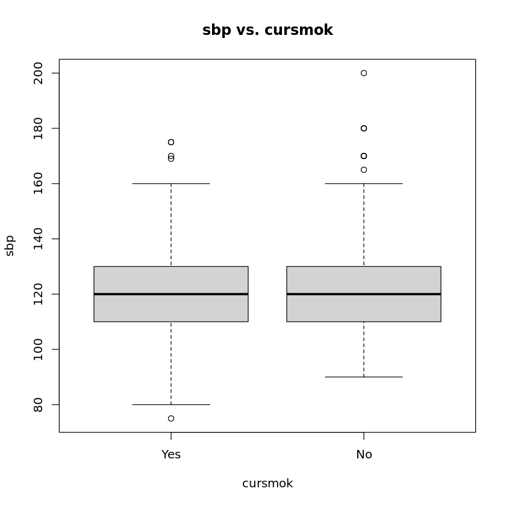

```r
sbpsmok1<-BioDS$sbp[BioDS$cursmok==1]
sbpsmok0<-BioDS$sbp[BioDS$cursmok==0]

sbpsmok1_meas<-fnmeasures(sbpsmok1)
sbpsmok0_meas<-fnmeasures(sbpsmok0)

# combine dataframes
rbind(sbpsmok1_meas,sbpsmok0_meas)

boxplot(sbpsmok1,sbpsmok0,main="sbp vs. cursmok",
        names=c('Yes','No'),xlab='cursmok',ylab='sbp')
```

- Στη Συστολική Πίεση δεν παρατηρείται μεγάλη διαφοροποίηση στα περιγραφικά μέτρα μεταξύ καπνιστών και μη.
- Η διάμεσος είναι ακριβώς η ίδια και στα δύο θηκογράμματα χωρίζει στη μέση τον θήκο, ο οποίος είναι ακριβώς ο ίδιος, αφού είναι ίδια ακριβώς τα τεταρτημόρια.
- Τα μουστάκια στους καπνιστές φαίνονται συμμετρικά.
- Και στις δύο περιπτώσεις υπάρχουν κάποια ouliers.

#### Διαστολική Πίεση - Καπνιστές & Μη

A matrix: 2 × 11 of type dbl

|  | Min. | 1st Qu. | Median | Mean | 3rd Qu. | Max. | Var | Stand.Dev. | Skewness | Kurtosis | Count |
| --- | --- | --- | --- | --- | --- | --- | --- | --- | --- | --- | --- |
| dbpsmok1_meas | 40 | 70 | 80 | 80.07179 | 85 | 130 | 148.8196 | 12.19916 | 0.377166 | 4.325314 | 195 |
| dbpsmok0_meas | 43 | 70 | 80 | 77.89407 | 85 | 120 | 142.5462 | 11.93927 | 0.360681 | 3.166927 | 236 |

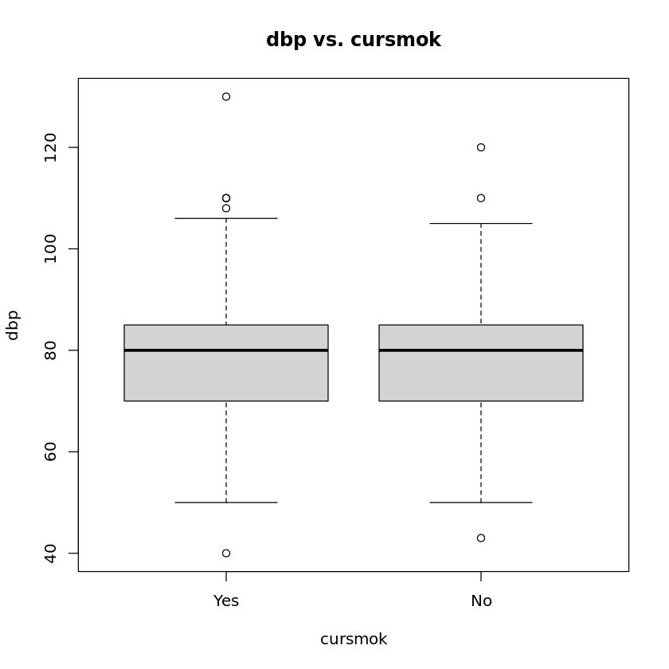

```r
dbpsmok1<-BioDS$dbp[BioDS$cursmok==1]
dbpsmok0<-BioDS$dbp[BioDS$cursmok==0]

dbpsmok1_meas<-fnmeasures(dbpsmok1)
dbpsmok0_meas<-fnmeasures(dbpsmok0)

# combine dataframes
rbind(dbpsmok1_meas, dbpsmok0_meas)

boxplot(dbpsmok1,dbpsmok0,main="dbp vs. cursmok",
        names=c('Yes','No'),xlab='cursmok',ylab='dbp')
```

- Όπως και στη Συστολική, στη Διαστολική Πίεση δεν παρατηρείται μεγάλη διαφοροποίηση στα περιγραφικά μέτρα μεταξύ καπνιστών και μη.
- Η διάμεσος και τα τεταρτημόρια είναι ακριβώς ίδια μεταξύ καπνιστών και μη αντίστοιχα.
- Όμως σε αυτή την περίπτωση και στα δύο θηκογράμματα η διάμεσος δεν χωρίζει συμμετρικά τον θήκο, καθώς το δεύτερο 25% των τιμών βρίσκονται μεταξύ 70-80 και το επόμενο 25% μεταξύ 80-85.
- Τα μουστάκια φαίνονται συμμετρικά.

#### Τριγλυκερίδια - Καπνιστές & Μη

A matrix: 2 × 11 of type dbl

|  | Min. | 1st Qu. | Median | Mean | 3rd Qu. | Max. | Var | Stand.Dev. | Skewness | Kurtosis | Count |
| --- | --- | --- | --- | --- | --- | --- | --- | --- | --- | --- | --- |
| tglsmok1_meas | 33 | 61.5 | 87.0 | 109.3897 | 133.5 | 587 | 5554.002 | 74.52518 | 2.961462 | 17.376326 | 195 |
| tglsmok0_meas | 27 | 64.0 | 88.5 | 103.5169 | 131.0 | 357 | 3489.749 | 59.07409 | 1.772705 | 7.216352 | 236 |

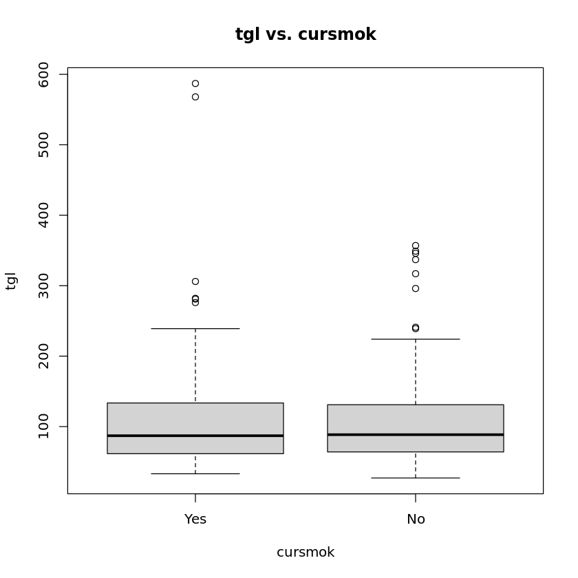

```r
tglsmok1<-BioDS$tgl[BioDS$cursmok==1]
tglsmok0<-BioDS$tgl[BioDS$cursmok==0]

tglsmok1_meas<-fnmeasures(tglsmok1)
tglsmok0_meas<-fnmeasures(tglsmok0)

# combine dataframes
rbind(tglsmok1_meas, tglsmok0_meas)

boxplot(tglsmok1,tglsmok0,main="tgl vs. cursmok",
        names=c('Yes','No'),xlab='cursmok',ylab='tgl')
```

- Η διαφοροποίηση στα περιγραφικά μέτρα μεταξύ καπνιστών και μη για τα Τριγλυκερίδια παρατηρείται κυρίως στη μέγιστη τιμή και τη διακύμανση. Φαίνεται ότι οι καπνιστές μπορεί να έχουν μεγάλες τιμές στις μετρήσεις για τα Τριγλυκερίδια.
- Η διάμεσος και τα τεταρτημόρια είναι πολύ κοντά μεταξύ καπνιστών και μη αντίστοιχα.
- Η διάμεσος δεν χωρίζει συμμετρικά τον θήκο και τα μουστάκια επίσης δεν είναι συμμετρικά.

#### Καλή Χοληστερόλη - Καπνιστές & Μη

A matrix: 2 × 11 of type dbl

|  | Min. | 1st Qu. | Median | Mean | 3rd Qu. | Max. | Var | Stand.Dev. | Skewness | Kurtosis | Count |
| --- | --- | --- | --- | --- | --- | --- | --- | --- | --- | --- | --- |
| hdlsmok1_meas | 25 | 40 | 48 | 49.42051 | 57.5 | 94 | 160.6882 | 12.67629 | 0.6547989 | 3.475304 | 195 |
| hdlsmok0_meas | 23 | 41 | 49 | 50.10169 | 57.0 | 90 | 165.3258 | 12.85791 | 0.5978025 | 2.952492 | 236 |

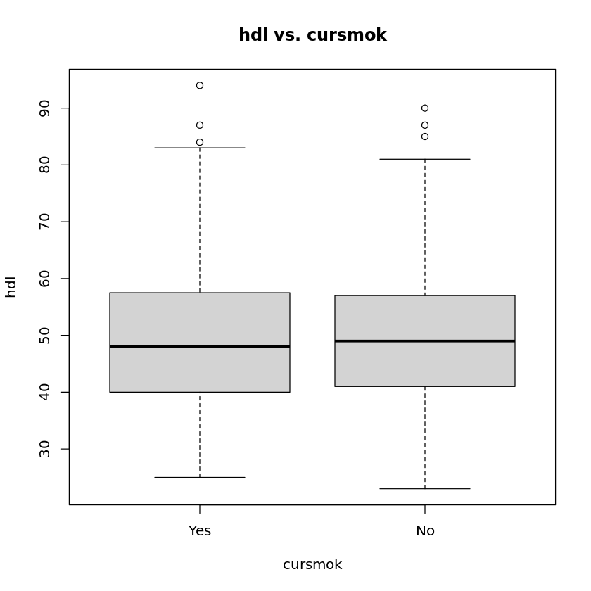

```r
hdlsmok1<-BioDS$hdl[BioDS$cursmok==1]
hdlsmok0<-BioDS$hdl[BioDS$cursmok==0]

hdlsmok1_meas<-fnmeasures(hdlsmok1)
hdlsmok0_meas<-fnmeasures(hdlsmok0)

# combine dataframes
rbind(hdlsmok1_meas,hdlsmok0_meas)

boxplot(hdlsmok1,hdlsmok0,main="hdl vs. cursmok"
        ,names=c('Yes','No'),xlab='cursmok',ylab='hdl')
```

- Στην Καλή Χοληστερόλη δεν παρατηρείται μεγάλη διαφοροποίηση στα περιγραφικά μέτρα μεταξύ καπνιστών και μη.
- Η διάμεσος είναι περίπου ίδια και στα δύο θηκογράμματα και χωρίζει περίπου στη μέση τον θήκο.
- Τα μουστάκια δεν είναι συμμετρικά.
- Και στις δύο περιπτώσεις υπάρχουν κάποια ouliers.

#### Κακή χοληστερόλη - Καπνιστές & Μη

A matrix: 2 × 11 of type dbl

|  | Min. | 1st Qu. | Median | Mean | 3rd Qu. | Max. | Var | Stand.Dev. | Skewness | Kurtosis | Count |
| --- | --- | --- | --- | --- | --- | --- | --- | --- | --- | --- | --- |
| ldlsmok1_meas | 32.2 | 89.650 | 112.05 | 117.3492 | 140.90 | 298.05 | 1508.430 | 38.83851 | 0.7659552 | 4.670019 | 195 |
| ldlsmok0_meas | 29.3 | 91.925 | 113.05 | 116.4614 | 140.85 | 270.20 | 1331.597 | 36.49105 | 0.5130085 | 3.766991 | 236 |

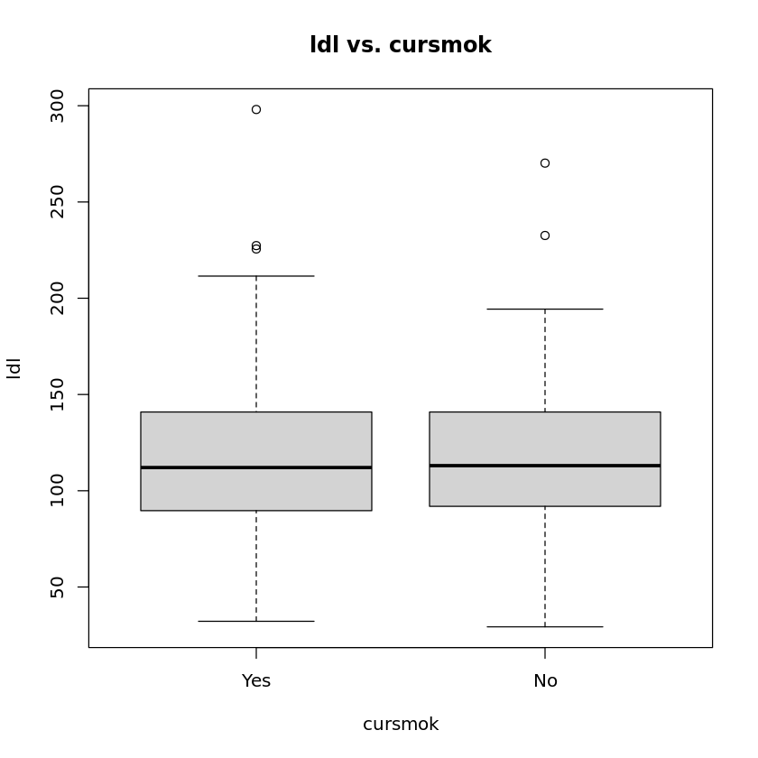

```r
ldlsmok1<-BioDS$ldl[BioDS$cursmok==1]
ldlsmok0<-BioDS$ldl[BioDS$cursmok==0]

ldlsmok1_meas<-fnmeasures(ldlsmok1)
ldlsmok0_meas<-fnmeasures(ldlsmok0)

# combine dataframes
rbind(ldlsmok1_meas, ldlsmok0_meas)

boxplot(ldlsmok1,ldlsmok0, main="ldl vs. cursmok"
        ,names=c('Yes','No'), xlab='cursmok', ylab='ldl')
```

- Στην Κακή Χοληστερόλη δεν παρατηρείται μεγάλη διαφοροποίηση στα περιγραφικά μέτρα μεταξύ καπνιστών και μη.
- Η διάμεσος είναι περίπου ίδια και στα δύο θηκογράμματα και δεν φαίνεται να χωρίζει συμμετρικά τον θήκο.
- Τα μουστάκια φαίνονται συμμετρικά.
- Και στις δύο περιπτώσεις υπάρχουν κάποια ouliers μακριά από το πάνω όριο του θηκογράμματος.

#### Δείκτης Μεσογειακής Διατροφής - Καπνιστές & Μη

A matrix: 2 × 11 of type dbl

|  | Min. | 1st Qu. | Median | Mean | 3rd Qu. | Max. | Var | Stand.Dev. | Skewness | Kurtosis | Count |
| --- | --- | --- | --- | --- | --- | --- | --- | --- | --- | --- | --- |
| MedDietScoresmok1_meas | 8 | 25.15183 | 26.52812 | 26.79977 | 28.32324 | 55 | 54.10220 | 7.355420 | 1.455250 | 8.248725 | 195 |
| MedDietScoresmok0_meas | 3 | 25.09160 | 26.80661 | 26.76219 | 28.56922 | 55 | 66.13992 | 8.132645 | 1.050045 | 7.673460 | 236 |

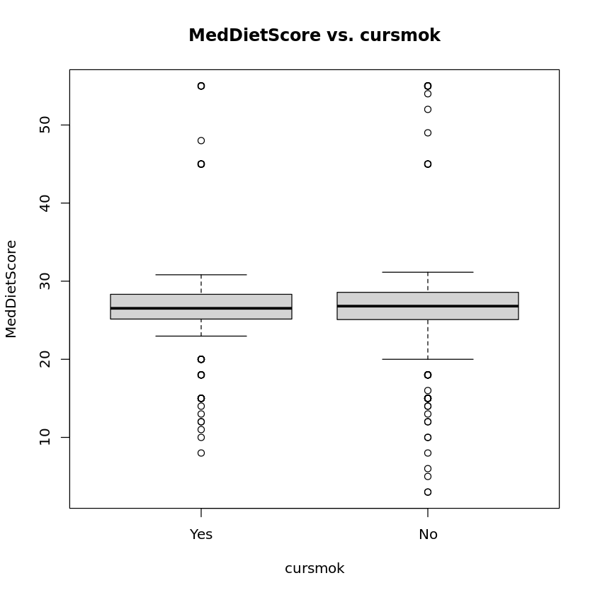

```r
MedDietScoresmok1<-BioDS$MedDietScore[BioDS$cursmok==1]
MedDietScoresmok0<-BioDS$MedDietScore[BioDS$cursmok==0]

MedDietScoresmok1_meas<-fnmeasures(MedDietScoresmok1)
MedDietScoresmok0_meas<-fnmeasures(MedDietScoresmok0)

# combine dataframes
rbind(MedDietScoresmok1_meas, MedDietScoresmok0_meas)

boxplot(MedDietScoresmok1,MedDietScoresmok0, main="MedDietScore vs. cursmok"
        ,names=c('Yes','No'), xlab='cursmok', ylab='MedDietScore')
```

- Για τον Δείκτη Μεσογειακής δεν παρατηρείται μεγάλη διαφοροποίηση στα περιγραφικά μέτρα μεταξύ καπνιστών και μη.
- Η διάμεσος είναι σχεδόν ίδια και στα δύο θηκογράμματα και χωρίζει συμμετρικά τον θήκο.
- Το διαφορετικό εδώ είναι ότι υπάρχουν πολλά ouliers και στο κάτω και στο πάνω όριο του θηκογράμματος, ενώ το εύρος των θηκογραμμάτων είναι πολύ συμπυκνωμένο.

### Α.3

Να υπολογίσετε τα κυριότερα μέτρα θέσης, μέτρα διασποράς και μέτρα μορφής των μεταβλητών των μεταβλητών του δείκτης μάζας σώματος, της συστολικής και διαστολικής πίεσης, των τριγλυκεριδίων, της καλής και κακής χοληστερόλης και του δείκτη μεσογειακής διατροφής για τα άτομα που ασκούνται σωματικά και μη. Να κατασκευασετε τα αντίστοιχα θηκογράμματα. Σχολιάστε.

#### Δείκτης Μάζας Σώματος - Ασκούνται Σωματικά & Μη

A matrix: 2 × 11 of type dbl

|  | Min. | 1st Qu. | Median | Mean | 3rd Qu. | Max. | Var | Stand.Dev. | Skewness | Kurtosis | Count |
| --- | --- | --- | --- | --- | --- | --- | --- | --- | --- | --- | --- |
| bmiPhysActivity1_meas | 17.57707 | 21.94257 | 24.75546 | 24.77845 | 27.34375 | 34.76562 | 13.13539 | 3.624278 | 0.1599337 | 2.383808 | 191 |
| bmiPhysActivity0_meas | 16.02307 | 22.76276 | 25.89852 | 26.51348 | 29.33146 | 52.51917 | 25.79771 | 5.079145 | 0.8307601 | 4.936131 | 240 |

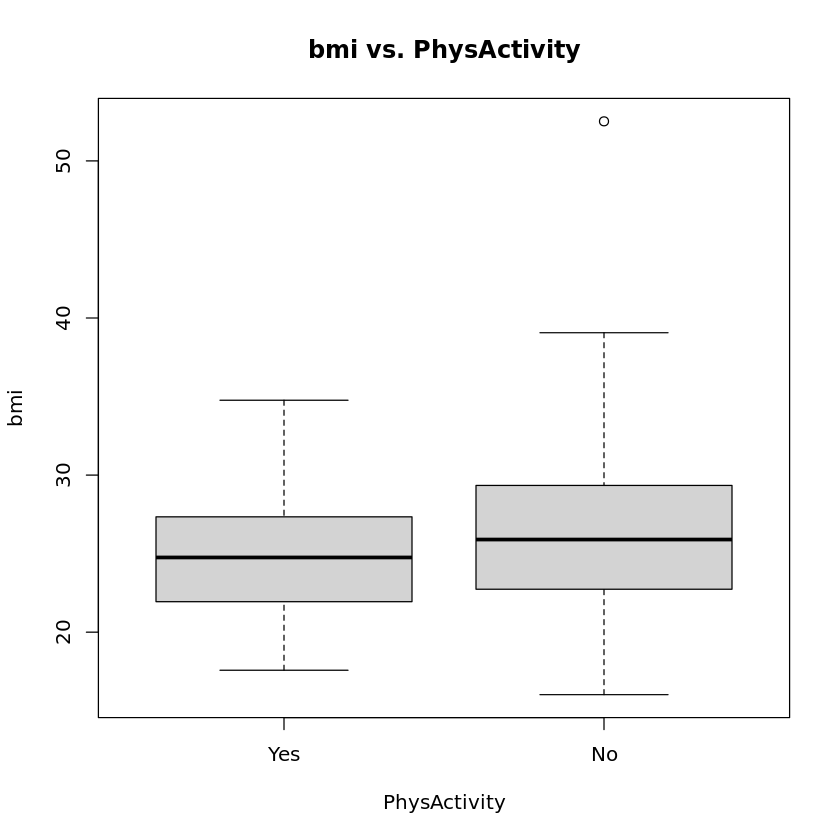

```r
bmiPhysActivity1<-BioDS$bmi[BioDS$PhysActivity==1]
bmiPhysActivity0<-BioDS$bmi[BioDS$PhysActivity==0]

bmiPhysActivity1_meas<-fnmeasures(bmiPhysActivity1)
bmiPhysActivity0_meas<-fnmeasures(bmiPhysActivity0)

rbind(bmiPhysActivity1_meas, bmiPhysActivity0_meas)
boxplot(bmiPhysActivity1,bmiPhysActivity0, main="bmi vs. PhysActivity",
        names=c('Yes','No'),xlab='PhysActivity',ylab='bmi')
```

- Ο Δείκτης Μάζας Σώματος φαίνεται λίγο αυξημένος και έχει μεγαλύτερο εύρος στα άτομα που δεν ασκούνται.
- Ο μέσος και η διάμεσος βρίσκονται κοντά και στις δυο κατηγορίες και τα δεδομένα δεν παρουσιάζουν μεγάλη διακύμανση.

#### Συστολική Πίεση - Ασκούνται Σωματικά & Μη

A matrix: 2 × 11 of type dbl

|  | Min. | 1st Qu. | Median | Mean | 3rd Qu. | Max. | Var | Stand.Dev. | Skewness | Kurtosis | Count |
| --- | --- | --- | --- | --- | --- | --- | --- | --- | --- | --- | --- |
| sbpPhysActivity1_meas | 80 | 110 | 120 | 119.9738 | 130 | 180 | 296.9519 | 17.23229 | 0.6269301 | 3.875778 | 191 |
| sbpPhysActivity0_meas | 75 | 110 | 120 | 122.2417 | 130 | 200 | 390.1422 | 19.75202 | 0.7459149 | 3.844089 | 240 |

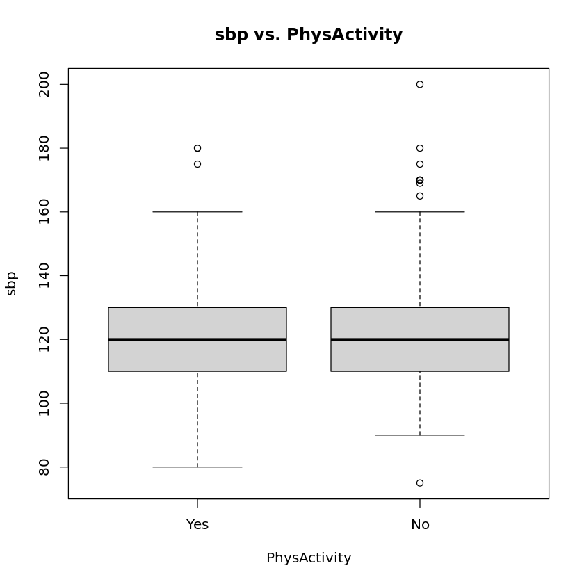

```r
sbpPhysActivity1<-BioDS$sbp[BioDS$PhysActivity==1]
sbpPhysActivity0<-BioDS$sbp[BioDS$PhysActivity==0]

sbpPhysActivity1_meas<-fnmeasures(sbpPhysActivity1)
sbpPhysActivity0_meas<-fnmeasures(sbpPhysActivity0)
# combine dataframes
rbind(sbpPhysActivity1_meas, sbpPhysActivity0_meas)

boxplot(sbpPhysActivity1,sbpPhysActivity0,main="sbp vs. PhysActivity"
        ,names=c('Yes','No'),xlab='PhysActivity',ylab='sbp')
```

- Σχετικά με την Συστολική Πίεση δεν παρατηρούνται ιδιαίτερες διαφοροποιήσεις μεταξύ ασκούμενων και μη.
- Οι τιμές των ορίων του θήκου και της διαμέσου είναι ακριβώς ίδιες και στις δύο κατηγορίες.
- Η διάμεσος και στα δύο θηκογράμματα χωρίζει ακριβώς στη μέση το θήκο.

#### Διαστολική Πίεση - Ασκούνται Σωματικά & Μη

A matrix: 2 × 11 of type dbl

|  | Min. | 1st Qu. | Median | Mean | 3rd Qu. | Max. | Var | Stand.Dev. | Skewness | Kurtosis | Count |
| --- | --- | --- | --- | --- | --- | --- | --- | --- | --- | --- | --- |
| dbpPhysActivity1_meas | 40 | 70 | 80 | 78.05759 | 85 | 130 | 135.6125 | 11.64528 | 0.5825149 | 4.721897 | 191 |
| dbpPhysActivity0_meas | 43 | 70 | 80 | 79.53333 | 85 | 120 | 154.3001 | 12.42176 | 0.2137094 | 3.133993 | 240 |

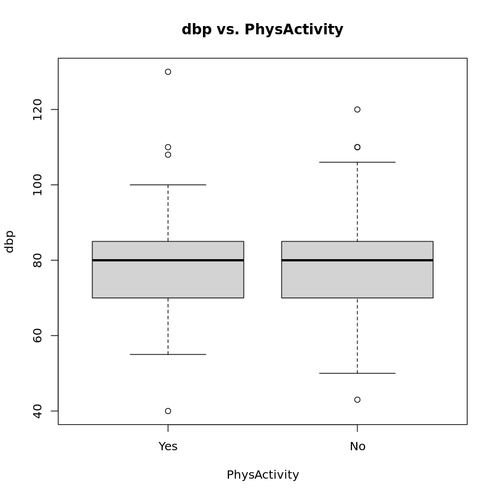

```r
dbpPhysActivity1<-BioDS$dbp[BioDS$PhysActivity==1]
dbpPhysActivity0<-BioDS$dbp[BioDS$PhysActivity==0]

dbpPhysActivity1_meas<-fnmeasures(dbpPhysActivity1)
dbpPhysActivity0_meas<-fnmeasures(dbpPhysActivity0)
# combine dataframes
rbind(dbpPhysActivity1_meas, dbpPhysActivity0_meas)

boxplot(dbpPhysActivity1,dbpPhysActivity0,main="dbp vs. PhysActivity",
        names=c('Yes','No'), xlab='PhysActivity', ylab='dbp')
```

- Όπως και στη Συστολική Πίεση έτσι και στη Διαστολική δεν παρουσιάζονται διαφοροποιήσεις μεταξύ ασκούμενων και μη.
- Και στις δύο κατηγορίες, η διάμεσος χωρίζει στο ένα τρίτο το θήκο και βρίσκεται στο ίδιο σημείο όπως και τα όρια του θήκου.

#### Τριγλυκερίδια - Ασκούνται Σωματικά & Μη

A matrix: 2 × 11 of type dbl

|  | Min. | 1st Qu. | Median | Mean | 3rd Qu. | Max. | Var | Stand.Dev. | Skewness | Kurtosis | Count |
| --- | --- | --- | --- | --- | --- | --- | --- | --- | --- | --- | --- |
| tglPhysActivity1_meas | 27 | 56 | 85 | 101.3194 | 131.50 | 349 | 3544.303 | 59.53405 | 1.474525 | 5.685061 | 191 |
| tglPhysActivity0_meas | 34 | 65 | 91 | 110.0375 | 134.25 | 587 | 5103.551 | 71.43914 | 3.029897 | 17.684707 | 240 |

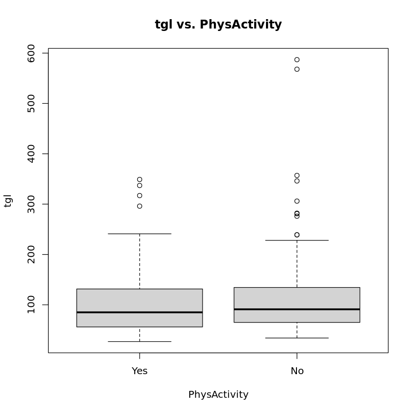

```r
tglPhysActivity1<-BioDS$tgl[BioDS$PhysActivity==1]
tglPhysActivity0<-BioDS$tgl[BioDS$PhysActivity==0]

tglPhysActivity1_meas<-fnmeasures(tglPhysActivity1)
tglPhysActivity0_meas<-fnmeasures(tglPhysActivity0)
# combine dataframes
rbind(tglPhysActivity1_meas, tglPhysActivity0_meas)

boxplot(tglPhysActivity1,tglPhysActivity0,main="tgl vs. PhysActivity",
        names=c('Yes','No'),xlab='PhysActivity',ylab='tgl')
```

- Οι τιμές για τα Τριγλυκερίδια στου μη ασκούμενους φαίνονται ελαφρώς αυξημένες.
- Στους μη ασκούμενους παρουσιάζεται μεγαλύτερη διακύμανση και κάποια αρκετά extreme values.

#### Καλή Χοληστερόλη - Ασκούνται Σωματικά & Μη

A matrix: 2 × 11 of type dbl

|  | Min. | 1st Qu. | Median | Mean | 3rd Qu. | Max. | Var | Stand.Dev. | Skewness | Kurtosis | Count |
| --- | --- | --- | --- | --- | --- | --- | --- | --- | --- | --- | --- |
| hdlPhysActivity1_meas | 28 | 42 | 51 | 52.04188 | 59 | 94 | 160.5246 | 12.66983 | 0.6394071 | 3.161017 | 191 |
| hdlPhysActivity0_meas | 23 | 39 | 47 | 48.00417 | 55 | 87 | 158.3305 | 12.58295 | 0.6467278 | 3.211697 | 240 |

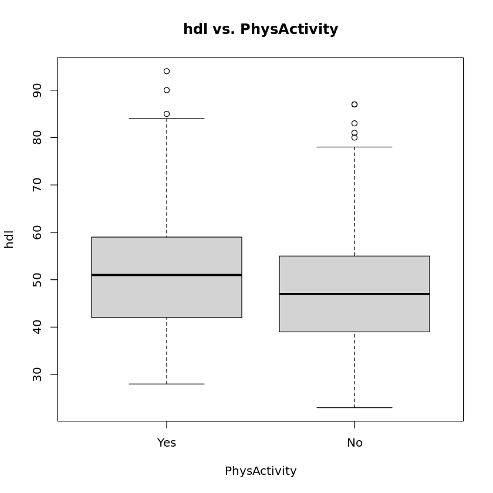

```r
hdlPhysActivity1<-BioDS$hdl[BioDS$PhysActivity==1]
hdlPhysActivity0<-BioDS$hdl[BioDS$PhysActivity==0]

hdlPhysActivity1_meas<-fnmeasures(hdlPhysActivity1)
hdlPhysActivity0_meas<-fnmeasures(hdlPhysActivity0)
# combine dataframes
rbind(hdlPhysActivity1_meas, hdlPhysActivity0_meas)

boxplot(hdlPhysActivity1,hdlPhysActivity0, main="hdl vs. PhysActivity",names=c('Yes','No'), xlab='PhysActivity', ylab='hdl')
```

- Από τα θηκογράμματα φαίνεται σαφώς ότι η τιμές για την Καλή Χοληστερόλη είναι αυξημένες για τους ασκούμενους, συνεπώς φαίνεται πως η φυσική κατάσταση επηρεάζει τις τιμές της.
- Η μέση τιμή είναι κοντά στη διάμεσο και στις δύο κατηγορίες αλλά φαίνεται ότι διαφέρουν σημαντικά μεταξύ των θηκογραμμάτων.

#### Κακή Χοληστερόλη - Ασκούνται Σωματικά & Μη

A matrix: 2 × 11 of type dbl

|  | Min. | 1st Qu. | Median | Mean | 3rd Qu. | Max. | Var | Stand.Dev. | Skewness | Kurtosis | Count |
| --- | --- | --- | --- | --- | --- | --- | --- | --- | --- | --- | --- |
| ldlPhysActivity1_meas | 29.30 | 89.000 | 112.4 | 115.6822 | 138.200 | 298.05 | 1553.187 | 39.41049 | 0.9564114 | 5.696524 | 191 |
| ldlPhysActivity0_meas | 37.65 | 91.175 | 113.4 | 117.8029 | 146.125 | 227.35 | 1297.326 | 36.01842 | 0.3280230 | 2.644432 | 240 |

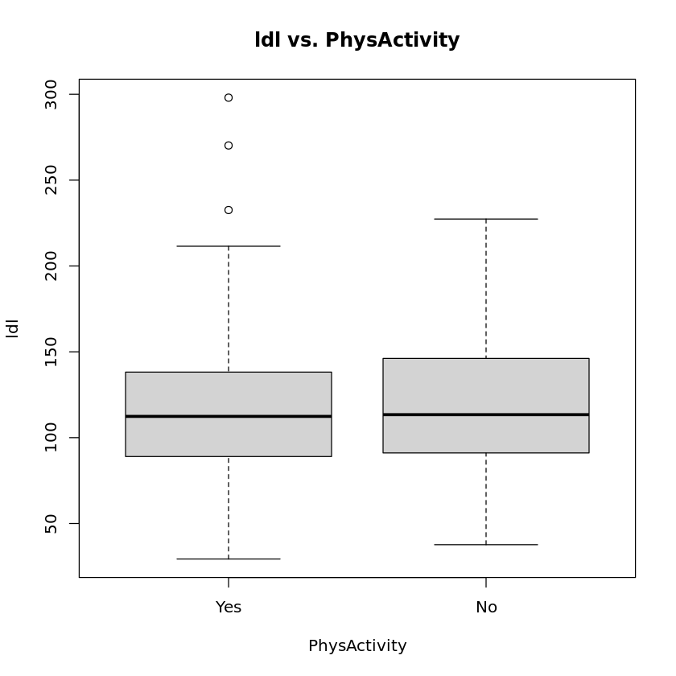

```r
ldlPhysActivity1<-BioDS$ldl[BioDS$PhysActivity==1]
ldlPhysActivity0<-BioDS$ldl[BioDS$PhysActivity==0]

ldlPhysActivity1_meas<-fnmeasures(ldlPhysActivity1)
ldlPhysActivity0_meas<-fnmeasures(ldlPhysActivity0)
# combine dataframes
rbind(ldlPhysActivity1_meas, ldlPhysActivity0_meas)

boxplot(ldlPhysActivity1,ldlPhysActivity0, main="ldl vs. PhysActivity",names=c('Yes','No'), xlab='PhysActivity', ylab='ldl')
```

- Σχετικά με την Κακή Χοληστερόλη η διάμεσος και το πρώτο τεταρτημόριο δεν διαφέρουν σημαντικά.
- Το 3ο τεταρτημόριο παρουσιάζεται ελαφρώς αυξημένο στα άτομα που δεν ασκούνται.

#### Δείκτης Μεσογειακής Διατροφής - Ασκούνται Σωματικά & Μη

A matrix: 2 × 11 of type dbl

|  | Min. | 1st Qu. | Median | Mean | 3rd Qu. | Max. | Var | Stand.Dev. | Skewness | Kurtosis | Count |
| --- | --- | --- | --- | --- | --- | --- | --- | --- | --- | --- | --- |
| MedDietScorePhysActivity1_meas | 6 | 25.20296 | 26.8791 | 26.58269 | 28.48893 | 55 | 55.50612 | 7.450243 | 1.102945 | 8.213424 | 191 |
| MedDietScorePhysActivity0_meas | 3 | 25.06654 | 26.4760 | 26.93558 | 28.48045 | 55 | 64.76758 | 8.047831 | 1.261987 | 7.709924 | 240 |

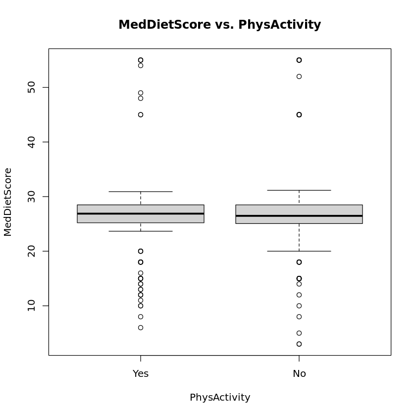

```r
MedDietScorePhysActivity1<-BioDS$MedDietScore[BioDS$PhysActivity==1]
MedDietScorePhysActivity0<-BioDS$MedDietScore[BioDS$PhysActivity==0]

MedDietScorePhysActivity1_meas<-fnmeasures(MedDietScorePhysActivity1)
MedDietScorePhysActivity0_meas<-fnmeasures(MedDietScorePhysActivity0)
# combine dataframes
rbind(MedDietScorePhysActivity1_meas,MedDietScorePhysActivity0_meas)

boxplot(MedDietScorePhysActivity1,MedDietScorePhysActivity0,main='MedDietScore vs. PhysActivity',
        names=c('Yes','No'),xlab='PhysActivity',ylab='MedDietScore')
```

- Για τον Δείκτη Μεσογειακής δεν παρατηρείται μεγάλη διαφοροποίηση στα περιγραφικά μέτρα μεταξύ ασκούμενων και μη.
- Η διάμεσος είναι σχεδόν ίδια και στα δύο θηκογράμματα.
- Το διαφορετικό εδώ είναι ότι υπάρχουν πολλά ouliers και στο κάτω και στο πάνω όριο του θηκογράμματος, ενώ το εύρος των θηκογραμμάτων είναι πολύ συμπυκνωμένο.

### Α.4

Να υπολογίσετε τα κυριότερα μέτρα θέσης, μέτρα διασποράς και μέτρα μορφής των μεταβλητών των μεταβλητών του δείκτης μάζας σώματος, της συστολικής και διαστολικής πίεσης, των τριγλυκεριδίων, της καλής και κακής χοληστερόλης και του δείκτη μεσογειακής διατροφής για τα άτομα που εμφάνισαν καρδιαγγειακή νόσο εντος της δεκαετίας και μη. Να κατασκευασετε τα αντίστοιχα θηκογράμματα. Σχολιάστε.

#### Δείκτης Μάζας Σώματος - Καρδιαγγειακή Νόσο & Μη

A matrix: 2 × 11 of type dbl

|  | Min. | 1st Qu. | Median | Mean | 3rd Qu. | Max. | Var | Stand.Dev. | Skewness | Kurtosis | Count |
| --- | --- | --- | --- | --- | --- | --- | --- | --- | --- | --- | --- |
| bmiCVD_10_yr1_meas | 19.43301 | 25.42001 | 27.45865 | 28.21219 | 31.23141 | 37.87401 | 17.31335 | 4.160931 | 0.3994391 | 2.708602 | 53 |
| bmiCVD_10_yr0_meas | 16.02307 | 21.97284 | 25.06971 | 25.39860 | 28.40534 | 52.51917 | 20.45964 | 4.523234 | 0.9588399 | 5.843678 | 378 |

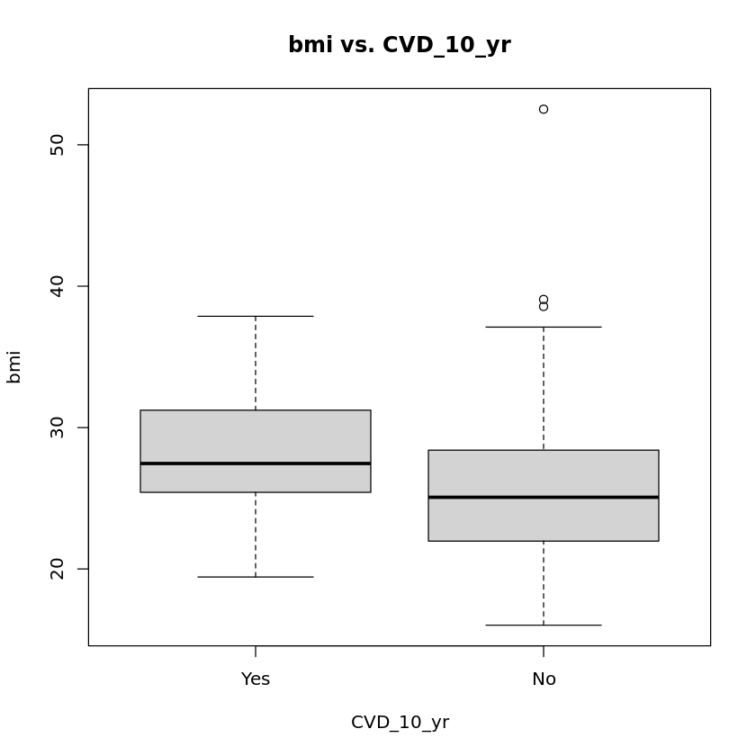

```r
bmiCVD_10_yr1<-BioDS$bmi[BioDS$CVD_10_yr==1]
bmiCVD_10_yr0<-BioDS$bmi[BioDS$CVD_10_yr==0]

bmiCVD_10_yr1_meas<-fnmeasures(bmiCVD_10_yr1)
bmiCVD_10_yr0_meas<-fnmeasures(bmiCVD_10_yr0)

# combine dataframes
rbind(bmiCVD_10_yr1_meas,bmiCVD_10_yr0_meas)

boxplot(bmiCVD_10_yr1,bmiCVD_10_yr0,main='bmi vs. CVD_10_yr',
        names=c('Yes','No'),xlab='CVD_10_yr',ylab='bmi')
```

- Από τα περιγραφικά μέτρα αλλά και από τα θηκογράμματα φαίνεται ότι ο Δείκτης Μάζας Σώματος σχετίζεται με την Καρδιαγγειακή Νόσο, συγκεκριμένα όσοι εμφάνισαν καρδιαγγειακή νόσο έχουν την τάση για αυξημένο Δείκτη Μάζα Σώματος.
- Είναι σημαντικό επίσης ότι το δείγμα με αυτούς που εμφάνισαν Καρδιαγγειακή Νόσο είναι πολύ μικρότερο (53 άτομα) σε σχέση με αυτούς που εν εμφάνισαν (378).

#### Συστολική Πίεση - Καρδιαγγειακή Νόσο & Μη

A matrix: 2 × 11 of type dbl

|  | Min. | 1st Qu. | Median | Mean | 3rd Qu. | Max. | Var | Stand.Dev. | Skewness | Kurtosis | Count |
| --- | --- | --- | --- | --- | --- | --- | --- | --- | --- | --- | --- |
| sbpCVD_10_yr1_meas | 100 | 120 | 130 | 131.9811 | 140 | 180 | 336.8650 | 18.35388 | 0.8670007 | 3.637920 | 53 |
| sbpCVD_10_yr0_meas | 75 | 110 | 120 | 119.7302 | 130 | 200 | 333.4708 | 18.26118 | 0.7454494 | 4.070991 | 378 |

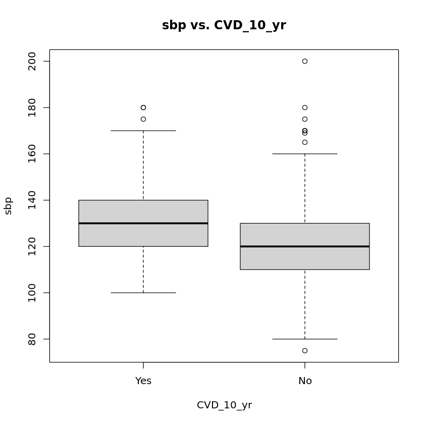

```r
sbpCVD_10_yr1<-BioDS$sbp[BioDS$CVD_10_yr==1]
sbpCVD_10_yr0<-BioDS$sbp[BioDS$CVD_10_yr==0]

sbpCVD_10_yr1_meas<-fnmeasures(sbpCVD_10_yr1)
sbpCVD_10_yr0_meas<-fnmeasures(sbpCVD_10_yr0)
# combine dataframes
rbind(sbpCVD_10_yr1_meas, sbpCVD_10_yr0_meas)

boxplot(sbpCVD_10_yr1,sbpCVD_10_yr0, main="sbp vs. CVD_10_yr",names=c('Yes','No'), xlab='CVD_10_yr', ylab='sbp')
```

- Από τα περιγραφικά μέτρα αλλά και από τα θηκογράμματα φαίνεται ότι και η Συστολική Πίεση είναι αυξημένη για τα άτομα που εμφάνισαν καρδιαγγειακή νόσο.
- Ο μέσος με τη διάμεσος κάθε ομάδας είναι κοντά αλλά απέχουν σημαντικά μεταξύ των δύο ομάδων.
- Τα τεταρτημόρια στους θήκους είναι συμμετρικά.
- Υπάρχει σημαντική διαφορά στην κατώτερη τιμή της Συστολικης Πίεσης, για αυτούς που εμφάνισαν καρδιαγγειακή νόσο είναι κατά 25 μονάδες αυξημένη.

#### Διαστολική Πίεση - Καρδιαγγειακή Νόσο & Μη

A matrix: 2 × 11 of type dbl

|  | Min. | 1st Qu. | Median | Mean | 3rd Qu. | Max. | Var | Stand.Dev. | Skewness | Kurtosis | Count |
| --- | --- | --- | --- | --- | --- | --- | --- | --- | --- | --- | --- |
| dbpCVD_10_yr1_meas | 70 | 80 | 85 | 86.30189 | 90 | 110 | 108.5610 | 10.41926 | 0.4362774 | 2.475946 | 53 |
| dbpCVD_10_yr0_meas | 40 | 70 | 80 | 77.83862 | 85 | 130 | 142.9739 | 11.95717 | 0.4299428 | 3.979217 | 378 |

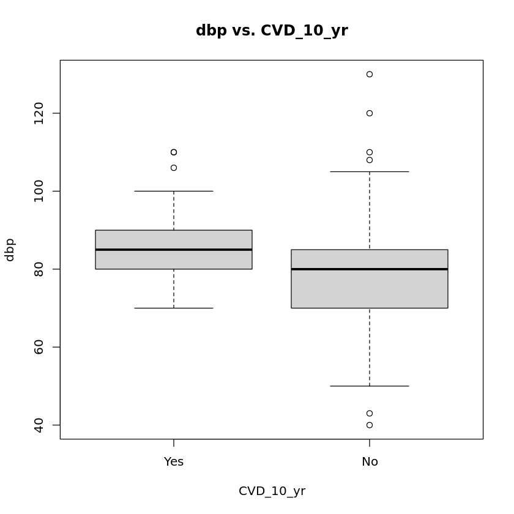

```r
dbpCVD_10_yr1<-BioDS$dbp[BioDS$CVD_10_yr==1]
dbpCVD_10_yr0<-BioDS$dbp[BioDS$CVD_10_yr==0]

dbpCVD_10_yr1_meas<-fnmeasures(dbpCVD_10_yr1)
dbpCVD_10_yr0_meas<-fnmeasures(dbpCVD_10_yr0)
# combine dataframes
rbind(dbpCVD_10_yr1_meas, dbpCVD_10_yr0_meas)

boxplot(dbpCVD_10_yr1,dbpCVD_10_yr0, main="dbp vs. CVD_10_yr",names=c('Yes','No'), xlab='CVD_10_yr', ylab='dbp')
```

- Όπως και στη Συστολική Πίεση έτσι και στη Διαστολική παρουσιάζεται αύξηση των τιμών για τα άτομα που εμφάνισαν καρδιαγγειακή νόσο.
- Υπάρχει κι εδώ σημαντική διαφορά στην κατώτερη τιμή της Διαστολικής Πίεσης, για αυτούς που εμφάνισαν καρδιαγγειακή νόσο είναι κατά 30 μονάδες αυξημένη.

#### Τριγλυκερίδια - Καρδιαγγειακή Νόσο & Μη

A matrix: 2 × 11 of type dbl

|  | Min. | 1st Qu. | Median | Mean | 3rd Qu. | Max. | Var | Stand.Dev. | Skewness | Kurtosis | Count |
| --- | --- | --- | --- | --- | --- | --- | --- | --- | --- | --- | --- |
| tglCVD_10_yr1_meas | 48 | 97 | 134 | 151.4528 | 167.00 | 568 | 7295.945 | 85.41630 | 2.692422 | 12.59842 | 53 |
| tglCVD_10_yr0_meas | 27 | 58 | 83 | 99.8254 | 120.75 | 587 | 3708.134 | 60.89445 | 2.477120 | 14.79871 | 378 |

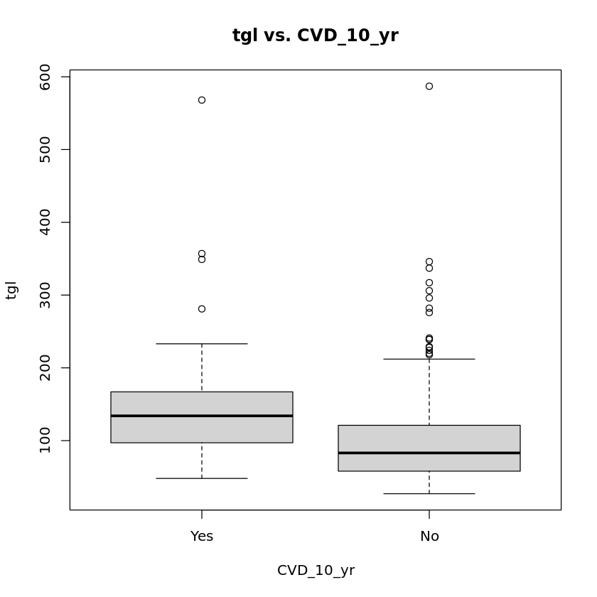

```r
tglCVD_10_yr1<-BioDS$tgl[BioDS$CVD_10_yr==1]
tglCVD_10_yr0<-BioDS$tgl[BioDS$CVD_10_yr==0]

tglCVD_10_yr1_meas<-fnmeasures(tglCVD_10_yr1)
tglCVD_10_yr0_meas<-fnmeasures(tglCVD_10_yr0)
# combine dataframes
rbind(tglCVD_10_yr1_meas, tglCVD_10_yr0_meas)

boxplot(tglCVD_10_yr1,tglCVD_10_yr0, main="tgl vs. CVD_10_yr",names=c('Yes','No'), xlab='CVD_10_yr', ylab='tgl')
```

- Από τα περιγραφικά μέτρα αλλά και από τα θηκογράμματα φαίνεται ότι και οι τιμές για τα Τριγλυκερίδια σχετίζονται με την καρδιαγγειακή νόσο. Είναι υψηλότερες για αυτούς που νόσησαν.
- Υπάρχει μεγάλη διαφορά στη μέση τιμή και τη διάμεσο των δύο κατηγοριών περίπου 50 μονάδες.